# Coursera Data Science Capstone - Milestone Report

Joe Bragg

Wednesday, March 25, 2015

## Project Objectives

The objective of this capstone project is to build a Shiny application that will predict the next word based on a phase of one or more words entered in a text box. The raw data is comprised of three en_US filtered text file samples originally from blogs, news articles and Twitter tweets from [HC Corpora](http://www.corpora.heliohost.org). Below is a summary of my analysis to date.

## Analysis to Date

### Downloading & Cleaning the Data

Below is a summary of the three en_US files we will be using.

| File | Size (Mb) | Lines | Words |
| --- | --- | --- | --- |
| en_US.blogs.txt | 200.42 | 899288 | 38154238 |
| en_US.news.txt | 196.28 | 77259 | 2693898 |
| en_US.twitter.txt | 159.36 | 2360148 | 30218166 |

With the goal in mind to predict the next word in a sentence based on the previous words, we will break each line of text into sentences. The number of sentences is 6455220 or on average 1.93 sentences per line of text.

8.5% of these sentences contain non-ASCII characters which can indicate non-English words or characters. Given the small percentage and the likely small contribution these will have to prediction, these sentences will be removed from the corpus.

Another consideration is whether or not to factor in numbers in the analysis. Just removing numbers could cause inaccurate predictions. Given numbers are used in various context including quantities, dates, measurements (ex. 4lbs) addresses, short-hand (ex. U 2, Me 2), etc., simple substitution with word equivalents or “#” would have limited value in our application. Given only 11.47% of the sentences have numbers, these sentences will be removed.

To complete the cleaning of the data all punctuation are removed (except single quotes in contractions), a list of profane words are replaced with (CENSORED), all text is converted to lower case letters and extra spaces are removed. If any of the resulting lines of text are shorter than 3 words, those lines are removed and the result is a clean corpus

As a final step, “<s>” is appended to the beginning and “<e>” is appended to the end of each line to indicate the start and end of each sentence.

This clean data set includes 4536063 lines with an average of 13.09 words each and a total of 59394197 words.

### Data Exploration

Given the large size of this corpus and limited computational resources, the cleaned data set is randomly sampled. 1/100th of the lines are used. This sampled corpus is then broken down into 1 - 5 N-grams. Below are frequency bar charts of the top 25 N-grams. It is interesting how quickly the frequencies drop off in all five bar charts.

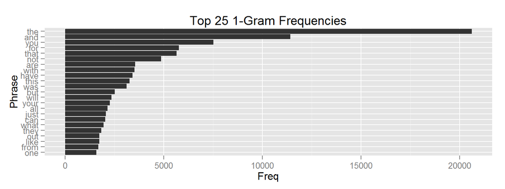

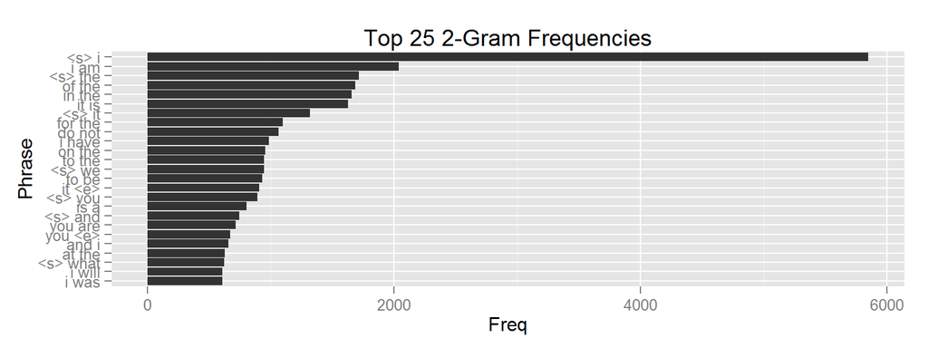

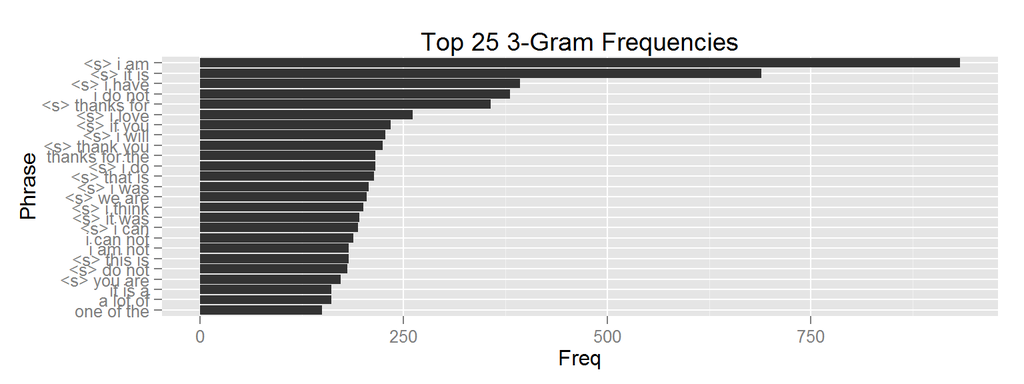

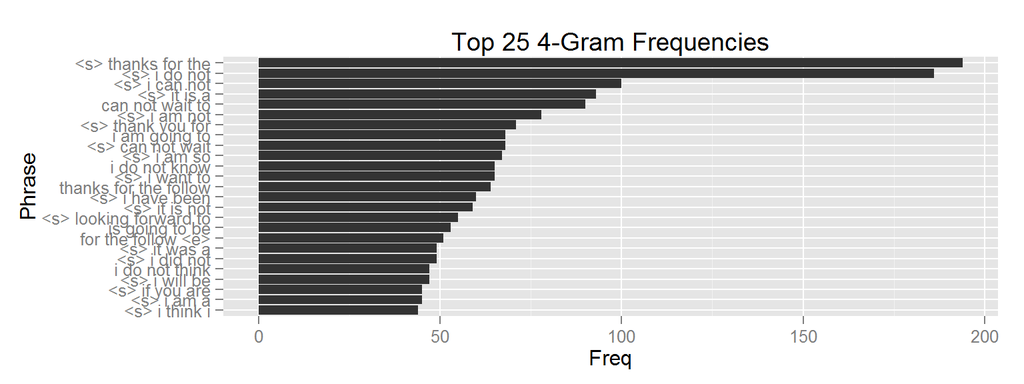

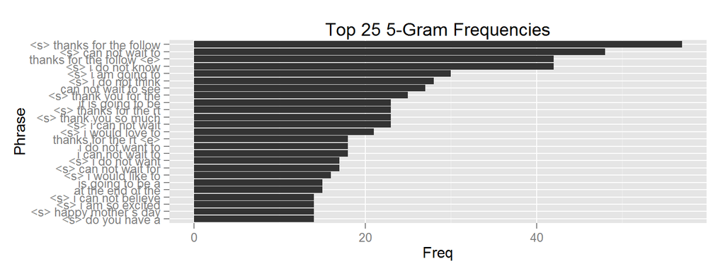

## Future Plans

The N-gram data sets along with the use of Markov Chains will be used to construct a prediction algorithm for the “next word” in a sentence. Basically, Markov Chains provide a way to predict the next word based on the previous N words given the probabilities from the sampled corpus. The prediction models will be trained on a subset of N-grams and tested on a separate subset of N-grams to ensure accuracy and that we are not “over-fitting” our model to the training data. The goal is analyze several models and choose the model that provides the best predictions.